# Course Project

R Programming

Javier Fong - 100437994

# 1 Description

As my final project for the R Programming class I decided to analyze the *Ames Housing Data set* collected [here](https://www.kaggle.com/c/house-prices-advanced-regression-techniques/data?select=train.csv).

The data set includes 81 features describing a wide range of characteristics of 1460 home in Ames, Iowa sold between 2006 and 2010.

For the purpose of this task, we will limit the variables to the following list:

Discrete variables:

- YearBuilt - Original Construction Year
- Bedroom - Number of bedrooms
- Kitchen - Number of Kitchens
- TotRmsAbvGrd - Total number of rooms in the house
- MoSold - Month of sale
- YrSold - Year of sale

Continuous variables:

- LotArea - Lot size in Square Foot
- 1stFlrSF - First Floor square feet
- 2ndFlrSF - Second Floor square feet
- SalePrice - Amount of sale

Categorical Variables:

- LotConfig - Lot configuration
- HouseStyle - Style of dwelling
- Exterior1st - Exterior covering on house
- Heating - Type of heating

# 2 Project

## 2.1 Libraries

I’ll use the following packages to perform the analysis:

- **dplyr**: Package for information manipulation.
- **reshape2**: Package for data shape manipulation.
- **caret**: Package for machine learning algorithms. CARET stands for **C**lassification **A**nd **RE**gression **T**raining.
- **ggplot2**: Graphs and plot functions.
- **moments** : Moments, kurtosis and skewness functions.
- **ggmosaic** : Mosaic plot functions.
- **gridExtra** : Plot arrangement functions.

```r
library(dplyr)
library(caret)
library(reshape2)
library(ggplot2)
library(moments)
library(ggmosaic)
library(kableExtra)
library(gridExtra)
library(waterfalls)
library(forcats)
library(caretEnsemble)
```

## 2.2 Data load

```r
dataset = read.csv("ames.csv")

dataset = dataset %>%
  select(
    LotArea
    , LotConfig
    , HouseStyle
    , YearBuilt
    , Exterior1st
    , Heating
    , FrstFlrSF = X1stFlrSF
    , ScndFlrSF = X2ndFlrSF
    , BedroomAbvGr
    , KitchenAbvGr
    , TotRmsAbvGrd
    , MoSold
    , YrSold
    , SalePrice
  )

dataset = dataset %>% unclass() %>% as.data.frame(stringsAsFactors = T)
dataset %>% str()
```

```
## 'data.frame':    1460 obs. of  14 variables:
##  $ LotArea     : int  8450 9600 11250 9550 14260 14115 10084 10382 6120 7420 ...
##  $ LotConfig   : Factor w/ 5 levels "Corner","CulDSac",..: 5 3 5 1 3 5 5 1 5 1 ...
##  $ HouseStyle  : Factor w/ 8 levels "1.5Fin","1.5Unf",..: 6 3 6 6 6 1 3 6 1 2 ...
##  $ YearBuilt   : int  2003 1976 2001 1915 2000 1993 2004 1973 1931 1939 ...
##  $ Exterior1st : Factor w/ 15 levels "AsbShng","AsphShn",..: 13 9 13 14 13 13 13 7 4 9 ...
##  $ Heating     : Factor w/ 6 levels "Floor","GasA",..: 2 2 2 2 2 2 2 2 2 2 ...
##  $ FrstFlrSF   : int  856 1262 920 961 1145 796 1694 1107 1022 1077 ...
##  $ ScndFlrSF   : int  854 0 866 756 1053 566 0 983 752 0 ...
##  $ BedroomAbvGr: int  3 3 3 3 4 1 3 3 2 2 ...
##  $ KitchenAbvGr: int  1 1 1 1 1 1 1 1 2 2 ...
##  $ TotRmsAbvGrd: int  8 6 6 7 9 5 7 7 8 5 ...
##  $ MoSold      : int  2 5 9 2 12 10 8 11 4 1 ...
##  $ YrSold      : int  2008 2007 2008 2006 2008 2009 2007 2009 2008 2008 ...
##  $ SalePrice   : int  208500 181500 223500 140000 250000 143000 307000 200000 129900 118000 ...
```

```r
dataset %>% summary()
```

```
##     LotArea         LotConfig      HouseStyle    YearBuilt     Exterior1st
##  Min.   :  1300   Corner : 263   1Story :726   Min.   :1872   VinylSd:515
##  1st Qu.:  7554   CulDSac:  94   2Story :445   1st Qu.:1954   HdBoard:222
##  Median :  9478   FR2    :  47   1.5Fin :154   Median :1973   MetalSd:220
##  Mean   : 10517   FR3    :   4   SLvl   : 65   Mean   :1971   Wd Sdng:206
##  3rd Qu.: 11602   Inside :1052   SFoyer : 37   3rd Qu.:2000   Plywood:108
##  Max.   :215245                  1.5Unf : 14   Max.   :2010   CemntBd: 61
##                                  (Other): 19                  (Other):128
##   Heating       FrstFlrSF      ScndFlrSF     BedroomAbvGr    KitchenAbvGr
##  Floor:   1   Min.   : 334   Min.   :   0   Min.   :0.000   Min.   :0.000
##  GasA :1428   1st Qu.: 882   1st Qu.:   0   1st Qu.:2.000   1st Qu.:1.000
##  GasW :  18   Median :1087   Median :   0   Median :3.000   Median :1.000
##  Grav :   7   Mean   :1163   Mean   : 347   Mean   :2.866   Mean   :1.047
##  OthW :   2   3rd Qu.:1391   3rd Qu.: 728   3rd Qu.:3.000   3rd Qu.:1.000
##  Wall :   4   Max.   :4692   Max.   :2065   Max.   :8.000   Max.   :3.000
##
##   TotRmsAbvGrd        MoSold           YrSold       SalePrice
##  Min.   : 2.000   Min.   : 1.000   Min.   :2006   Min.   : 34900
##  1st Qu.: 5.000   1st Qu.: 5.000   1st Qu.:2007   1st Qu.:129975
##  Median : 6.000   Median : 6.000   Median :2008   Median :163000
##  Mean   : 6.518   Mean   : 6.322   Mean   :2008   Mean   :180921
##  3rd Qu.: 7.000   3rd Qu.: 8.000   3rd Qu.:2009   3rd Qu.:214000
##  Max.   :14.000   Max.   :12.000   Max.   :2010   Max.   :755000
##
```

## 2.3 Discrete Variables

```r
disc_vars = dataset %>%
  dplyr::select(
    YearBuilt
    , BedroomAbvGr
    , KitchenAbvGr
    , TotRmsAbvGrd
    , MoSold
    , YrSold
  )

disc_vars %>%
  melt() %>%
  group_by(variable) %>%
  summarise(
    min_v = min(value)
    , max_v = max(value)
    , diff_values = n_distinct(value)
    , mode_v = which.max(tabulate(value))
  ) %>%
  mutate(across(where(is.numeric), round, 2)) %>%
  kbl(
    format = "html"
    , caption = "Discrete Variable Summary"
    , col.names = c(
      "Variable"
      , "Min"
      , "Max"
      , "# of Values"
      , "Mode")
  ) %>%
  kable_styling()
```

Table 2.1: Discrete Variable Summary

| Variable | Min | Max | # of Values | Mode |
| --- | --- | --- | --- | --- |
| YearBuilt | 1872 | 2010 | 112 | 2006 |
| BedroomAbvGr | 0 | 8 | 8 | 3 |
| KitchenAbvGr | 0 | 3 | 4 | 1 |
| TotRmsAbvGrd | 2 | 14 | 12 | 6 |
| MoSold | 1 | 12 | 12 | 6 |
| YrSold | 2006 | 2010 | 5 | 2009 |

With the above summary we get an idea of the nature of the discrete variables in our data set. All of them are discrete ordered variables, meaning they’re are ordered by nature. One comes after the other. And with the exception of YearBuilt, all of them have very few distinct values.

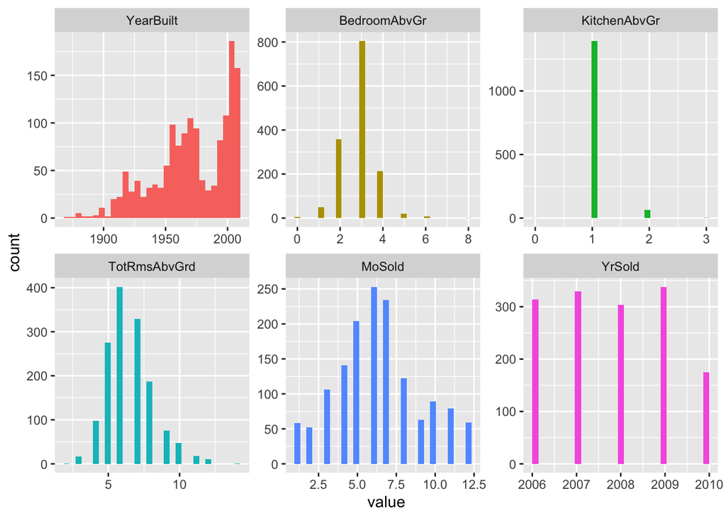

Figure 2.1: Discrete Variables Histogram

```r
disc_vars %>%
  melt() %>%
  ggplot(
    aes(x = value, fill = variable)
  ) +
  geom_histogram() +
  facet_wrap(~variable, scale = "free") +
  theme(legend.position = "none")
```

Now with the help of the histogram plots above, we get a clear idea of the group size of each value in the variables.

## 2.4 Continuous Variables

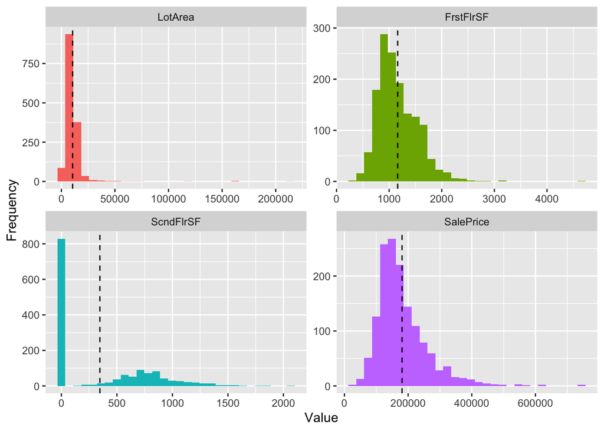

Figure 2.2: Countinuous Variable Histograms

```r
cont_vars = dataset %>%
  dplyr::select(
    LotArea
    , FrstFlrSF
    , ScndFlrSF
    , SalePrice
  )

cont_vars %>%
  melt() %>%
  ggplot(
    aes(x = value, fill = variable)
  ) +
  geom_histogram() +
  geom_vline(
    data = cont_vars %>%
      melt() %>%
      group_by(variable) %>%
      summarise(mean_v =  mean(value))
    , aes(xintercept = mean_v)
    , linetype = "dashed"
  ) +
  facet_wrap(~variable, scale = "free") +
  theme(
    legend.position = "none"
  ) +
  ylab("Frequency") +
  xlab("Value")
```

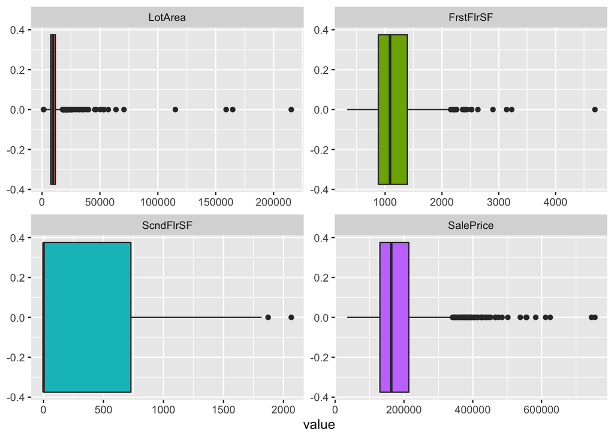

Figure 2.3: Countinuous Variable Boxplot

```r
cont_vars = dataset %>%
  dplyr::select(
    LotArea
    , FrstFlrSF
    , ScndFlrSF
    , SalePrice
  )

cont_vars %>%
  melt() %>%
  ggplot(
    aes(x = value, fill = variable)
  ) +
  geom_boxplot() +
  facet_wrap(~variable, scale = "free") +
  theme(
    legend.position = "none"
  )
```

```r
cont_vars %>%
  melt() %>%
  group_by(variable) %>%
  summarise(
    min_v = min(value)
    , max_v = max(value)
    , mean_v = mean(value)
    , sd_v = sd(value)
    , skweness_v = skewness(value)
    , kurtosis_v = kurtosis(value)
  ) %>%
  mutate(across(where(is.numeric), round, 2)) %>%
  kbl(
    format = "html"
    , caption = "Continuous Variable Summary"
    , col.names = c(
      "Variable"
      , "Min"
      , "Max"
      , "Mean"
      , "Standard Dev."
      , "Skewness"
      , "Kurtosis")
  ) %>%
  kable_styling()
```

Table 2.2: Continuous Variable Summary

| Variable | Min | Max | Mean | Standard Dev. | Skewness | Kurtosis |
| --- | --- | --- | --- | --- | --- | --- |
| LotArea | 1300 | 215245 | 10516.83 | 9981.26 | 12.20 | 205.54 |
| FrstFlrSF | 334 | 4692 | 1162.63 | 386.59 | 1.38 | 8.72 |
| ScndFlrSF | 0 | 2065 | 346.99 | 436.53 | 0.81 | 2.44 |
| SalePrice | 34900 | 755000 | 180921.20 | 79442.50 | 1.88 | 9.51 |

Now we have a more precise values of our continuous variables using the above estimators. We’ll interpret variable by variable:

- In the case of the lot area, we get a mean value of $10,516.83 ft^2$ with a standard dev. of $9,981.26ft^2$. This sd seems to be influenced by the presence of the outliers observed in the boxplots. This variable also has the highest value of skewness (12.2), meaning most values are centered around the left tail of the distribution, as observed in the histogram. We also have an abnormally large value for the kurtosis in contrast with the rest of the variables. This high value means we’re dealing with a *leptokurtic distribution*, meaning we have high concentration of data on the tails.
- We can gather the same conclusions from the parameters of the FrstFlrSF and the SalePrice variables. The SD seems to indicate “relative” smaller dispersity in the observations with the mean. Although this variables have skewness and kurtosis values closer to 0 than the LotArea, they’re still positive. Meaning most of our data are centered in the left tail of the distribution and a higher concentration of points in the tails than in the center.
- The ScndFlrSF has the lower values for the skewness and kurtosis, meaning it might be the closest one resembling a normal distribution. Still, it is not a good match for it.

## 2.5 Categorical Variables

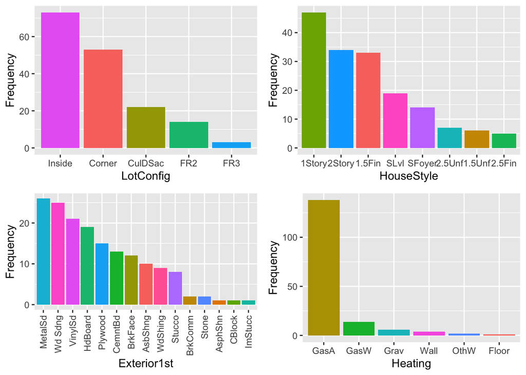

Figure 2.4: Categorial Variables Distributions

```r
cat_vars = dataset %>%
  dplyr::select_if(is.factor) %>%
  dplyr::group_by_all() %>%
  dplyr::summarise(cnt = n())



lotConfigPlot = cat_vars %>% ggplot(aes(x = fct_infreq(LotConfig), fill = LotConfig)) + geom_bar() + ylab("Frequency") + theme(legend.position = 'none') + xlab("LotConfig")
houseStylePlot = cat_vars %>% ggplot(aes(x = fct_infreq(HouseStyle), fill = HouseStyle )) + geom_bar()+ ylab("Frequency") + theme(legend.position = 'none')+ xlab("HouseStyle")
exteriorPlot = cat_vars %>% ggplot(aes(x = fct_infreq(Exterior1st), fill = Exterior1st)) + geom_bar()+ ylab("Frequency") + theme(legend.position = 'none',axis.text.x = element_text(angle = 90, vjust = 0.5, hjust=1))+ xlab("Exterior1st")
heatingPlot = cat_vars %>% ggplot(aes(x = fct_infreq(Heating), fill = Heating)) + geom_bar()+ ylab("Frequency") + theme(legend.position = 'none')+ xlab("Heating")

grid.arrange(
  lotConfigPlot
  , houseStylePlot
  , exteriorPlot
  , heatingPlot
  , ncol = 2
)
```

From the above plots we can gather the following information:

- LotConfig: 5 existing groups, but 2 (corner, inside) concentrate most of the information.
- HouseStyle: 8 categories, with 3 considerably larger than the others.
- Exterior1st: The most diverse variable. 15 group with 10 of them with considerable number of observations.
- Heating: 6 groups, but just 1 gather almost all the properties.

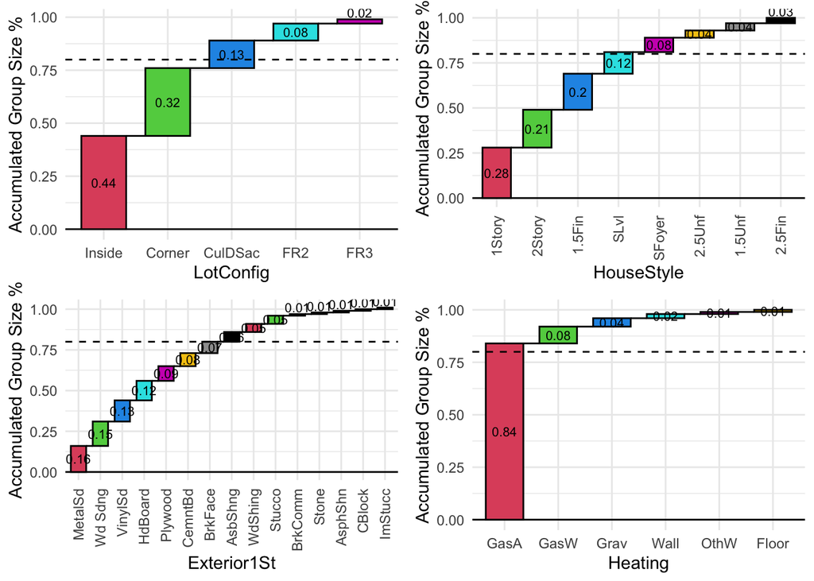

Figure 2.5: Categorical Variables Accumulated Group Size %

```r
lotConfig_groupsize = cat_vars$LotConfig %>%
  table() %>%
  prop.table() %>%
  sort(decreasing = T) %>%
  data.frame() %>%
  mutate(across(where(is.numeric), round, 2)) %>%
  waterfall(linetype = 1, fill_by_sign = F, fill_colours = 2:(nrow(.)+1)) +
  geom_hline(yintercept = 0.8, linetype = "dashed") +
  theme_minimal() +
  xlab("LotConfig") + ylab("Accumulated Group Size %")

houseStyle_groupsize = cat_vars$HouseStyle %>%
  table() %>%
  prop.table() %>%
  sort(decreasing = T) %>%
  data.frame() %>%
  mutate(across(where(is.numeric), round, 2)) %>%
  waterfall(linetype = 1, fill_by_sign = F, fill_colours = 2:(nrow(.)+1)) +
  geom_hline(yintercept = 0.8, linetype = "dashed") +
  theme_minimal() +
  theme(axis.text.x = element_text(angle = 90, vjust = 0.5, hjust=1))+
  xlab("HouseStyle") + ylab("Accumulated Group Size %")

exterior_groupsize = cat_vars$Exterior1st %>%
  table() %>%
  prop.table() %>%
  sort(decreasing = T) %>%
  data.frame() %>%
  mutate(across(where(is.numeric), round, 2)) %>%
  waterfall(linetype = 1, fill_by_sign = F, fill_colours = 2:(nrow(.)+1)) +
  geom_hline(yintercept = 0.8, linetype = "dashed") +
  theme_minimal()+
  theme(axis.text.x = element_text(angle = 90, vjust = 0.5, hjust=1))+
  xlab("Exterior1St") + ylab("Accumulated Group Size %")

heating_groupsize = cat_vars$Heating %>%
  table() %>%
  prop.table() %>%
  sort(decreasing = T) %>%
  data.frame() %>%
  mutate(across(where(is.numeric), round, 2)) %>%
  waterfall(linetype = 1, fill_by_sign = F, fill_colours = 2:(nrow(.)+1)) +
  geom_hline(yintercept = 0.8, linetype = "dashed") +
  theme_minimal()+
  xlab("Heating") + ylab("Accumulated Group Size %")

grid.arrange(
  lotConfig_groupsize
  , houseStyle_groupsize
  , exterior_groupsize
  , heating_groupsize
  , ncol = 2
)
```

With the above waterfall plot we can know how many of the groups account for 80% of our observations. In the case of **LotConfig** we just need the 2 larger groups, *Inside* and *Corner* to group 76% of all the properties in our data set. In **HouseStyle** we need 4 out of the 8 groups to get 81% of the observations. The **Exterior1st**, as the most distributed variable, need 7/15 to sum up the 80% of the entries. At last we see that 84% of the observations in the **Heating** variable belong to the *GasA* category.

## 2.6 Analysis by Group

```r
table(dataset$HouseStyle) %>% sort(decreasing = T )
```

```
##
## 1Story 2Story 1.5Fin   SLvl SFoyer 1.5Unf 2.5Unf 2.5Fin
##    726    445    154     65     37     14     11      8
```

Now, we’ll analyze each group in the *HouseStyle* variable. From the previous section we know that the variable is divided in 8 different groups with the following distribution:

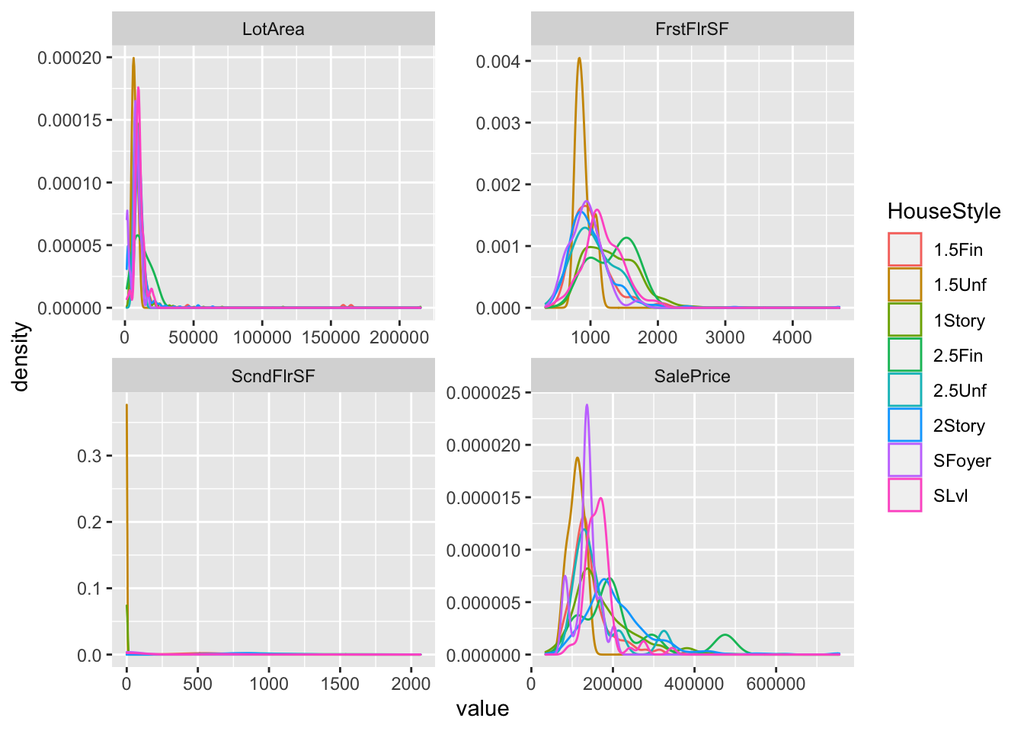

Figure 2.6: Continuous Variables Density by HouseStyle Group

```r
hsdataset = dataset %>%
  dplyr::select_if(names(.)=="HouseStyle" | sapply(., is.numeric))

hsdataset %>%
  select(HouseStyle, LotArea, FrstFlrSF, ScndFlrSF, SalePrice) %>%
  melt(id = c("HouseStyle")) %>%
  ggplot(
    aes(
      x = value
      , col = HouseStyle
    )
  )  +
  geom_density() +
  facet_wrap(~variable, scale = "free")
```

First we take a look at the densities of the our continuous variables for each of the house style groups. For the lotArea and the ScndFlrSF variables we cannot get a clear view of any difference in the densities given the scale of the plots. Now for the FrstFlrSF variable, we do see some variation on each group. The *1.5Unf* sees to have the highest concentration of points near the $1000ft^2$. Then the rest of groups look like they have a more even distribution. It is interesting to notice that some of them, as *SLvl* and *2.5Fin* seem to be bimodal distributions, meaning there are 2 high concentration values of first floor area. For the Sale price, it is difficult to draw any conclusion from the densities of each group. It is still worth mentioning that there is a mode for *2.5Fin* group pretty far right in the plot. This is actually expected, given that this category is possibly the one with larger construction area, raising the price of this properties.

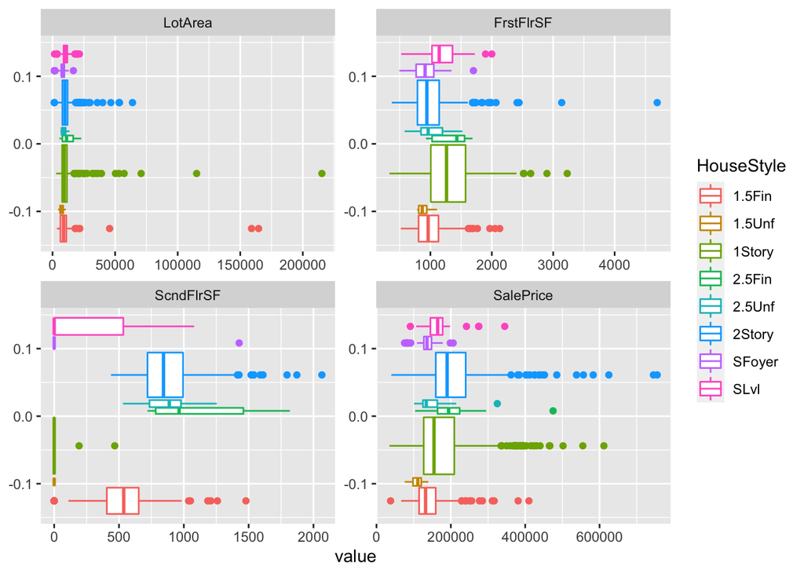

Figure 2.7: Continuous Variables Boxplot by HouseStyle Group

```r
hsdataset %>%
  select(HouseStyle, LotArea, FrstFlrSF, ScndFlrSF, SalePrice) %>%
  melt(id = c("HouseStyle")) %>%
  ggplot(
    aes(
      x = value
      , col = HouseStyle
    )
  )  +
  geom_boxplot(varwidth = T) +
  facet_wrap(~variable, scale = "free")
```

Now we use to the boxplots to get a more concise idea of the summary of the groups. Notice that the width of each box is directly proportional to the group size, meaning larger groups have wider boxes. Given the nature of our continuous variables, we should not expect to find any grand insight by house style group. Three out of the 4 variables measure floor area or the area on which the propertie is build. These variables are independent of the distribution of the house.

That been said, the fourth variable, *SalePrice*, should have some relationship to the house distribution. In its boxplot we notice that the highest sold properties are those with 2 stories. Then we can compare properties with the same number of floors, but changing if they’re still under construction. We see that those properties with finalized constructions (*1.5Fin* & *2.5Fin*) sell for highest prices than those with unfinished works (*1.5Unf* & *2.5Unf*)

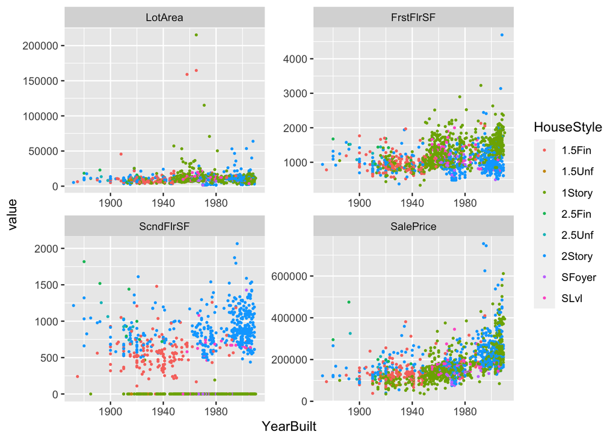

Figure 2.8: Continuous Variables Scattered by HouseStyle Group and Year Built

```r
hsdataset %>%
  select(HouseStyle, YearBuilt, LotArea, FrstFlrSF, ScndFlrSF, SalePrice) %>%
  melt(id = c("HouseStyle", "YearBuilt")) %>%
  ggplot(
    aes(
      y = value
      , x = YearBuilt
      , col = HouseStyle
    )
  )  +
  geom_point(size = 0.5) +
  facet_wrap(~variable, scale = "free")
```

At last we tried to see if the there’s been any interesting development though the years in this groups. We can see that the lot area has remained relatively the same for the last 100 years. But do notice that the construction of *1Story* houses has become more frequent in the last 50 years. Keeping in this same line, this *1Story* houses have seen an upward trend in its size sice the 1980’s. We see the same pattern for the *2Story* houses, but with in more recent years. They become more often constructed in the early 2000’s, and keep getting a larger second floor. At last we see an increment in sale price for all groups as the construction in more recent.

## 2.7 The CARET Package

Now we’ll use the caret package to make some predictions over our data set.

### 2.7.1 Model

#### 2.7.1.1 Train and Test Set

First we’ll divide our data set into a training and testing sets so we have a partition to train our model and a untouched one to test its performance.

```r
set.seed(100)
train.ind = createDataPartition(
  dataset$HouseStyle
  , p = 0.8
  , list = F
  , times = 1
)

trainset = dataset[train.ind,]
testset = dataset[-train.ind,]
```

Our train and test set chosen at random have the following sizes:

- Train Set: 1171 rows.
- Test Set: 289 rows.

#### 2.7.1.2 Predictions

##### 2.7.1.2.1 Random Forest

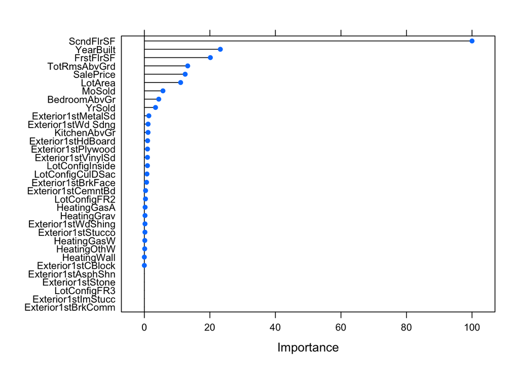

```r
rf_fit = train(
  HouseStyle ~ .
  , data = trainset
  , method = "rf"
)

plot(
  varImp(rf_fit)
)
```

We build a random forest model to predict the *HouseStyle* base on all the other variables on our data set. From the above plot we notice that the most relevant variables the model found to predict this values are **ScndFlrSF**, **YearBuilt** and **FrstFlSF** above all others.

Now let’s see how this model performs against unknown data.

```r
confusionMatrix(
  reference = as.factor(testset$HouseStyle)
  , as.factor(predict(rf_fit, testset))
)
```

```
## Confusion Matrix and Statistics
##
##           Reference
## Prediction 1.5Fin 1.5Unf 1Story 2.5Fin 2.5Unf 2Story SFoyer SLvl
##     1.5Fin     21      0      0      0      0      5      0    0
##     1.5Unf      0      0      0      0      0      0      0    0
##     1Story      1      2    144      0      0      0      6    8
##     2.5Fin      0      0      0      0      0      0      0    0
##     2.5Unf      0      0      0      0      0      0      0    0
##     2Story      8      0      0      1      2     83      0    3
##     SFoyer      0      0      1      0      0      0      1    1
##     SLvl        0      0      0      0      0      1      0    1
##
## Overall Statistics
##
##                Accuracy : 0.8651
##                  95% CI : (0.8202, 0.9022)
##     No Information Rate : 0.5017
##     P-Value [Acc > NIR] : < 0.00000000000000022
##
##                   Kappa : 0.7778
##
##  Mcnemar's Test P-Value : NA
##
## Statistics by Class:
##
##                      Class: 1.5Fin Class: 1.5Unf Class: 1Story Class: 2.5Fin
## Sensitivity                0.70000       0.00000        0.9931       0.00000
## Specificity                0.98069       1.00000        0.8819       1.00000
## Pos Pred Value             0.80769           NaN        0.8944           NaN
## Neg Pred Value             0.96578       0.99308        0.9922       0.99654
## Prevalence                 0.10381       0.00692        0.5017       0.00346
## Detection Rate             0.07266       0.00000        0.4983       0.00000
## Detection Prevalence       0.08997       0.00000        0.5571       0.00000
## Balanced Accuracy          0.84035       0.50000        0.9375       0.50000
##                      Class: 2.5Unf Class: 2Story Class: SFoyer Class: SLvl
## Sensitivity                0.00000        0.9326       0.14286     0.07692
## Specificity                1.00000        0.9300       0.99291     0.99638
## Pos Pred Value                 NaN        0.8557       0.33333     0.50000
## Neg Pred Value             0.99308        0.9688       0.97902     0.95819
## Prevalence                 0.00692        0.3080       0.02422     0.04498
## Detection Rate             0.00000        0.2872       0.00346     0.00346
## Detection Prevalence       0.00000        0.3356       0.01038     0.00692
## Balanced Accuracy          0.50000        0.9313       0.56788     0.53665
```

This model got an accuracy of 86% with a 95% confidence interval of 82% to 90%. That’s an overall good model. But we can go even deeper and analize the performance of the model to predict each group. We see that the model is actually really good at finding 1Story of 2Story houses (high sensitivity for those categories). That’s to be expected given that those are the 2 larger groups on our data set. On the contrary, the model is pretty bad at finding properties that belong to all the other categories. For example, out of the 7 *SFoyer* properties in the test set, 6 got classified as *1Story* houses. The same with the *SLvl* group, where out of the 13 observations in the test set, 8 got classified as *1Story* and 3 as *2Story*.

##### 2.7.1.2.2 Naive Bayes

```r
nb_fit = train(
  x = trainset %>% select(-HouseStyle)
  , y = trainset$HouseStyle
  , data = trainset
  , method = "nb"
)

confusionMatrix(
  reference = as.factor(testset$HouseStyle)
  , as.factor(predict(nb_fit, testset))
)
```

```
## Confusion Matrix and Statistics
##
##           Reference
## Prediction 1.5Fin 1.5Unf 1Story 2.5Fin 2.5Unf 2Story SFoyer SLvl
##     1.5Fin     19      0      0      0      2      7      0    0
##     1.5Unf      3      1      4      0      0      0      0    0
##     1Story      2      1    141      0      0      0      6    9
##     2.5Fin      0      0      0      0      0      0      0    0
##     2.5Unf      0      0      0      0      0      2      0    0
##     2Story      6      0      0      1      0     80      0    4
##     SFoyer      0      0      0      0      0      0      1    0
##     SLvl        0      0      0      0      0      0      0    0
##
## Overall Statistics
##
##                Accuracy : 0.8374
##                  95% CI : (0.7897, 0.878)
##     No Information Rate : 0.5017
##     P-Value [Acc > NIR] : < 0.00000000000000022
##
##                   Kappa : 0.7363
##
##  Mcnemar's Test P-Value : NA
##
## Statistics by Class:
##
##                      Class: 1.5Fin Class: 1.5Unf Class: 1Story Class: 2.5Fin
## Sensitivity                0.63333       0.50000        0.9724       0.00000
## Specificity                0.96525       0.97561        0.8750       1.00000
## Pos Pred Value             0.67857       0.12500        0.8868           NaN
## Neg Pred Value             0.95785       0.99644        0.9692       0.99654
## Prevalence                 0.10381       0.00692        0.5017       0.00346
## Detection Rate             0.06574       0.00346        0.4879       0.00000
## Detection Prevalence       0.09689       0.02768        0.5502       0.00000
## Balanced Accuracy          0.79929       0.73780        0.9237       0.50000
##                      Class: 2.5Unf Class: 2Story Class: SFoyer Class: SLvl
## Sensitivity                0.00000        0.8989       0.14286     0.00000
## Specificity                0.99303        0.9450       1.00000     1.00000
## Pos Pred Value             0.00000        0.8791       1.00000         NaN
## Neg Pred Value             0.99303        0.9545       0.97917     0.95502
## Prevalence                 0.00692        0.3080       0.02422     0.04498
## Detection Rate             0.00000        0.2768       0.00346     0.00000
## Detection Prevalence       0.00692        0.3149       0.00346     0.00000
## Balanced Accuracy          0.49652        0.9219       0.57143     0.50000
```

```r
svm_fit = train(
    HouseStyle ~ .
  , data = trainset
  , method = "svmLinear"
  , preProcess = c("center", "scale")
)

confusionMatrix(
  reference = as.factor(testset$HouseStyle)
  , as.factor(predict(svm_fit, testset))
)
```

```
## Confusion Matrix and Statistics
##
##           Reference
## Prediction 1.5Fin 1.5Unf 1Story 2.5Fin 2.5Unf 2Story SFoyer SLvl
##     1.5Fin     18      0      0      0      0      7      0    2
##     1.5Unf      0      0      0      0      0      0      0    0
##     1Story      3      2    145      0      0      0      6    9
##     2.5Fin      0      0      0      0      0      1      0    0
##     2.5Unf      0      0      0      0      0      0      0    0
##     2Story      9      0      0      1      2     81      0    2
##     SFoyer      0      0      0      0      0      0      1    0
##     SLvl        0      0      0      0      0      0      0    0
##
## Overall Statistics
##
##                Accuracy : 0.8478
##                  95% CI : (0.8011, 0.8871)
##     No Information Rate : 0.5017
##     P-Value [Acc > NIR] : < 0.00000000000000022
##
##                   Kappa : 0.7473
##
##  Mcnemar's Test P-Value : NA
##
## Statistics by Class:
##
##                      Class: 1.5Fin Class: 1.5Unf Class: 1Story Class: 2.5Fin
## Sensitivity                0.60000       0.00000        1.0000       0.00000
## Specificity                0.96525       1.00000        0.8611       0.99653
## Pos Pred Value             0.66667           NaN        0.8788       0.00000
## Neg Pred Value             0.95420       0.99308        1.0000       0.99653
## Prevalence                 0.10381       0.00692        0.5017       0.00346
## Detection Rate             0.06228       0.00000        0.5017       0.00000
## Detection Prevalence       0.09343       0.00000        0.5709       0.00346
## Balanced Accuracy          0.78263       0.50000        0.9306       0.49826
##                      Class: 2.5Unf Class: 2Story Class: SFoyer Class: SLvl
## Sensitivity                0.00000        0.9101       0.14286     0.00000
## Specificity                1.00000        0.9300       1.00000     1.00000
## Pos Pred Value                 NaN        0.8526       1.00000         NaN
## Neg Pred Value             0.99308        0.9588       0.97917     0.95502
## Prevalence                 0.00692        0.3080       0.02422     0.04498
## Detection Rate             0.00000        0.2803       0.00346     0.00000
## Detection Prevalence       0.00000        0.3287       0.00346     0.00000
## Balanced Accuracy          0.50000        0.9201       0.57143     0.50000
```

#### 2.7.1.3 Ensemble

```r
trainControl = trainControl(
  method = "repeatedcv"
  , number = 5
  , repeats = 3
  , savePredictions = "final"
  , classProbs = T
)

algList = c("rf", "svmLinear")

models = caretList(
  HouseStyle ~ .
  , data = trainset
  , trControl = trainControl()
  , methodList = algList
  , preProcess = c("center", "scale")
)

results = resamples(models)
summary(results)
```

```
##
## Call:
## summary.resamples(object = results)
##
## Models: rf, svmLinear
## Number of resamples: 25
##
## Accuracy
##                Min.   1st Qu.    Median      Mean   3rd Qu.      Max. NA's
## rf        0.8449074 0.8571429 0.8693587 0.8676697 0.8772727 0.8888889    0
## svmLinear 0.8217593 0.8329571 0.8423529 0.8403058 0.8465116 0.8668224    0
##
## Kappa
##                Min.   1st Qu.    Median      Mean   3rd Qu.      Max. NA's
## rf        0.7391822 0.7660374 0.7865269 0.7830723 0.7972295 0.8149307    0
## svmLinear 0.7075281 0.7306296 0.7393679 0.7409502 0.7530851 0.7776968    0
```